# R Notebook

Roman Alberto Velez Jimenez

```r
library(tidyverse)
knitr::opts_chunk$set(echo = FALSE, error = TRUE, include = TRUE)
```

# Ejercicio 1: Verosimilitud

## Pregunta 1.1: Qué es esta función

Esta función devuelve la log verosimilitud de una distribución binomial $X ~ \text{Bin}(n, p)$ para el parámetro $p$ donde $X$ es si hay o no error, y $p$ representa la probabilidad de ese error. Para estimarlo, se observan $N$ datos, de los cuales $N_{\text{err}}$ contienen error.

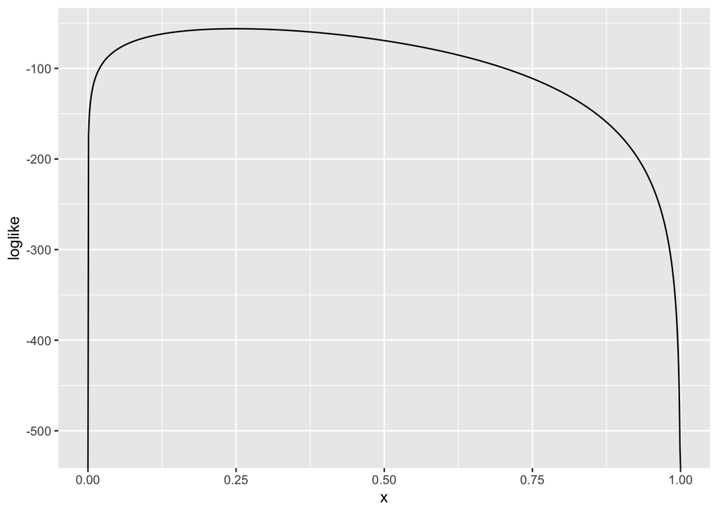

## Pregunta 1.2: Construir con $N = 500$ y $N_{\text{err}} = 121$

De qué parámetros depende esta ultima función? **Respuesta:** *Está función depende de $N_{err}$, puesto que $N$ es fija. Los datos observados son $N_{err}$, que en este caso es 121.*

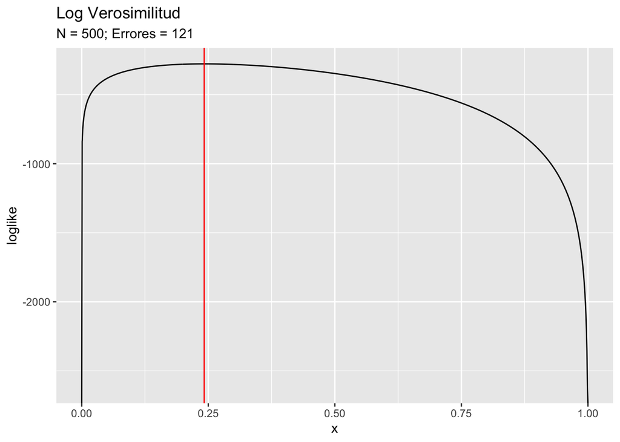

## 1.3: Usar MV

Bajo la muestra $X = N_{\text{err}} = 121$ para $N = 500$, se encontrará $p$ vía máxima verosomilitud, es decir optimizando `loglike` para $X$ y $N$ fija.

```
## Maxima verosimilitud, p: 0.242
```

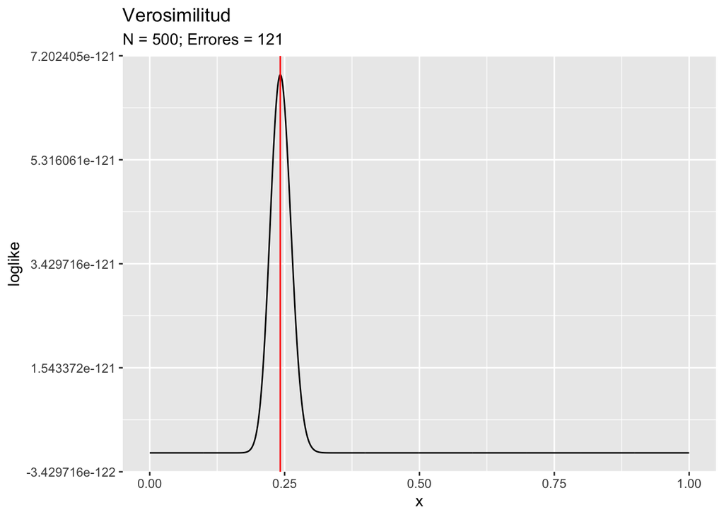

## 1.4: $N_{err} = 317$

Se reptie el ejercicio para 317 errores.

```
## Maxima verosimilitud, p: 0.634
```

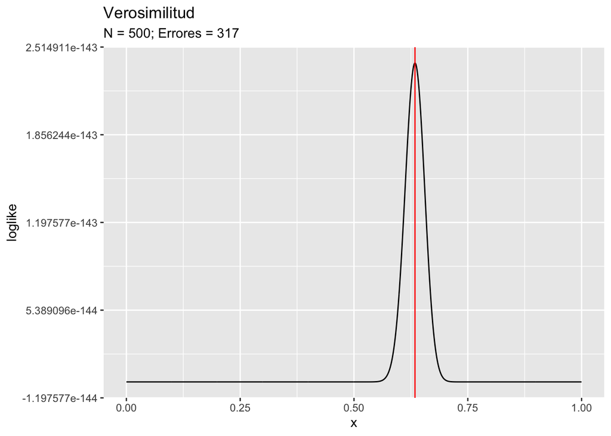

# Pregunta 2: Normal

## 2.1: Escribir la verosimilitud para una muestra de tamaño $n$

### Verosmilitud

La verosimilitud para $X ~ \sim \mathcal{N}(\mu, \sigma)$ está dada por:
$$\mathcal{L}(\mu, \sigma^2; \underline{x}) =
\prod_{i=1}^{n} \frac{1}{\sqrt{2\pi\sigma^2}} \exp\left(-\frac{(x_{i} -
\mu)^2}{2\sigma^2}\right).$$

### Log Versomilitud

Por consiguiente, la log verosimilitud está dada por
$$\ell(\mu, \sigma^2; \underline{x}) =
\sum_{i}^{n}-\frac{1}{2}\log(2\pi\sigma^2) - \frac{(x_{i} -
\mu)^2}{2\sigma^2}. = -n\log(\sigma) - \sum_{i}^{n}\frac{(x_{i} -
\mu)^2}{2\sigma^2}$$
Nótese que $\sqrt{2 \pi}$ desparece de $\ell$ ya que es una constante.

## 2.2: Estimar $\mu$, $\sigma$

Para ejemplificar MV para una normal, generamos su media y desviación estándar de forma aleatoria.

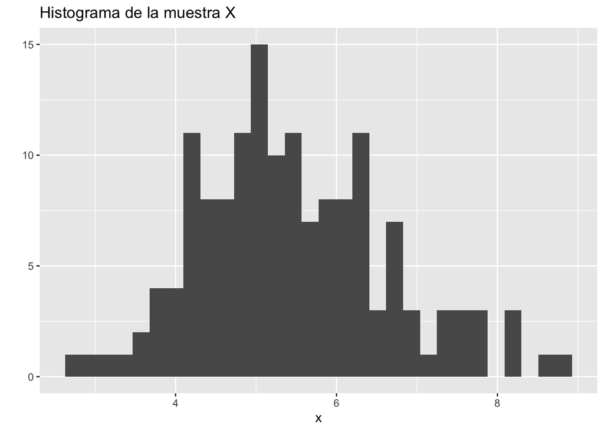

Mediante el método plug-in, encontramos sus parámetros

```
## media plug in: 5.45362032577995
```

```
## sigma plug in: 1.18967352410231
```

Mediante MV encontramos sus parámetros, fija la muestra $\underline{x}$.

```
## media mv in: 5.45371324724823
```

```
## sigma mv in: 1.18586985947739
```

Los valores reales son

```
## media real in: 5.56851705652662
```

```
## sigma real in: 1.24459880962968
```